# Assessment v1

Ahmed SOROUR

2024-02-10

# Load data

```r
library(tidyverse)

#load data
carehome_data <- read.csv("carehomedata_assessment2024.csv")
head(carehome_data)
```

```
##   participant_id sex age_at_recording age_at_death physical_activity
## 1              1   M         82.85775     83.71636               low
## 2              2   M         81.19990     81.19990               low
## 3              3   M         81.46722     83.34632             light
## 4              4   F         72.37810     72.37810               low
## 5              5   M         85.71573     85.71573             light
## 6              6   F         88.01906     91.10457           sitting
##   moderate_activity      BMI carehome_id
## 1          47.33063 23.76049           1
## 2          45.28279 26.31856           2
## 3          48.88195 22.20059           1
## 4          51.38753 26.04468           2
## 5          51.08582 23.19571           2
## 6          38.74970 26.98510           1
```

```r
demographic_summary <- carehome_data %>%
  select(participant_id, sex, age_at_recording, BMI, carehome_id) %>%
  summary()

# # Print the summary table
# print(demographic_summary)

# Print the summary table
knitr::kable(demographic_summary, caption = "Summary of Demographic and Baseline Characteristics")
```

Summary of Demographic and Baseline Characteristics

|  | participant_id | sex | age_at_recording | BMI | carehome_id |
| --- | --- | --- | --- | --- | --- |
|  | Min. : 1 | Length:341 | Min. :66.53 | Min. :19.27 | Min. :1.000 |
|  | 1st Qu.: 86 | Class :character | 1st Qu.:76.41 | 1st Qu.:23.74 | 1st Qu.:1.000 |
|  | Median :171 | Mode :character | Median :79.95 | Median :25.12 | Median :1.000 |
|  | Mean :171 | NA | Mean :79.85 | Mean :24.92 | Mean :1.493 |
|  | 3rd Qu.:256 | NA | 3rd Qu.:83.45 | 3rd Qu.:26.20 | 3rd Qu.:2.000 |
|  | Max. :341 | NA | Max. :93.49 | Max. :29.81 | Max. :2.000 |

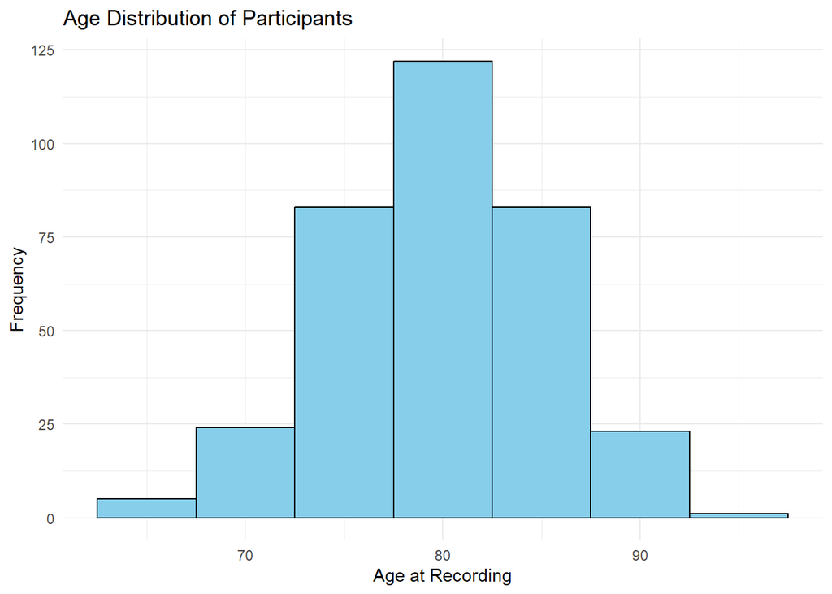

```r
# Age Distribution Graph
ggplot(carehome_data, aes(x = age_at_recording)) +
  geom_histogram(binwidth = 5, fill = "skyblue", color = "black") +
  labs(title = "Age Distribution of Participants",
       x = "Age at Recording",
       y = "Frequency") +
  theme_minimal()
```

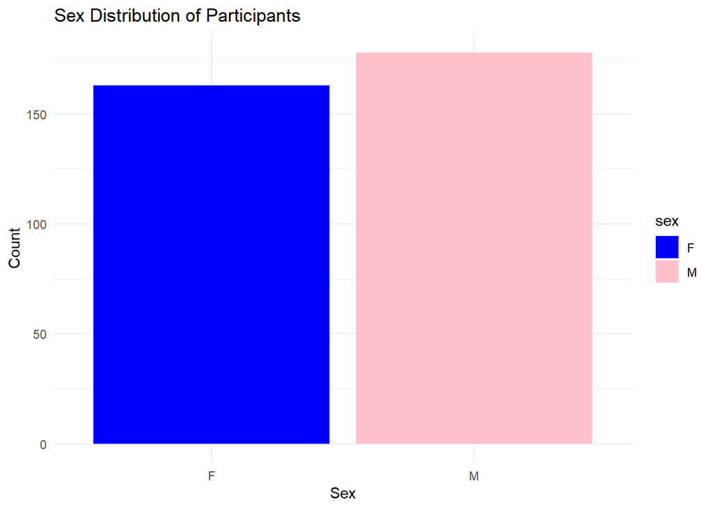

```r
# Sex Distribution Graph
ggplot(carehome_data, aes(x = sex, fill = sex)) +
  geom_bar() +
  labs(title = "Sex Distribution of Participants",
       x = "Sex",
       y = "Count") +
  theme_minimal() +
  scale_fill_manual(values = c("blue", "pink"))
```

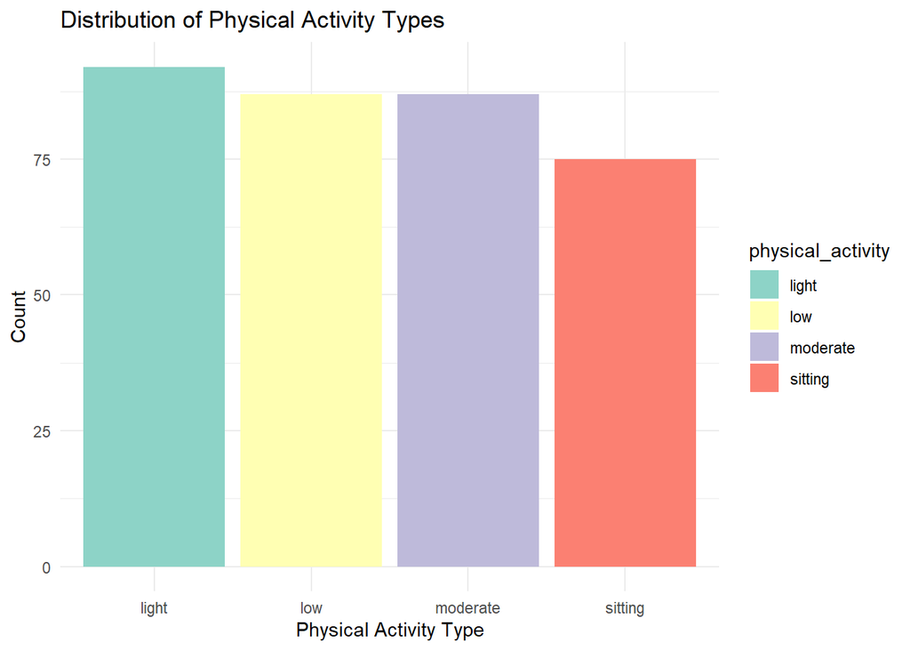

```r
# Physical Activity Type Distribution
ggplot(carehome_data, aes(x = physical_activity, fill = physical_activity)) +
  geom_bar() +
  labs(title = "Distribution of Physical Activity Types",
       x = "Physical Activity Type",
       y = "Count") +
  theme_minimal() +
  scale_fill_brewer(palette = "Set3")
```

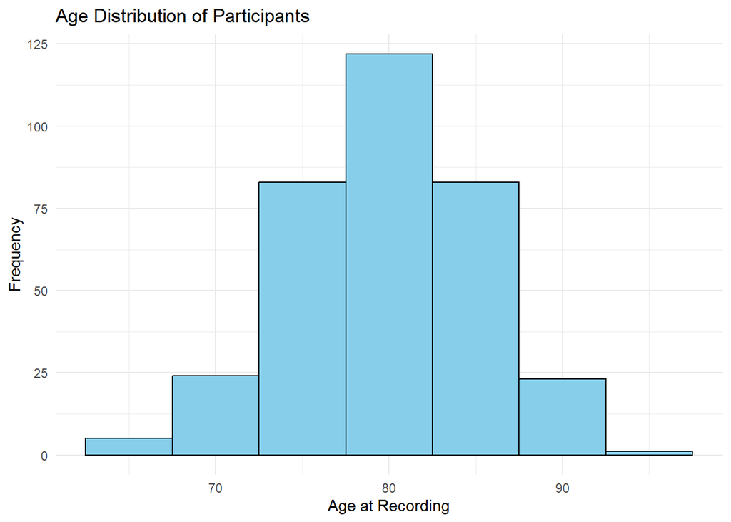

```r
# Generate a graph for Age Distribution
age_distribution <- ggplot(carehome_data, aes(x = age_at_recording)) +
  geom_histogram(binwidth = 5, fill = "skyblue", color = "black") +
  labs(title = "Age Distribution of Participants",
       x = "Age at Recording",
       y = "Frequency") +
  theme_minimal()

# Print the graph
print(age_distribution)
```

```r
# Conduct a t-test to compare BMI between the two care homes if applicable
t_test_results <- t.test(BMI ~ carehome_id, data = carehome_data)

# Print t-test results
print(t_test_results)
```

```
##
##  Welch Two Sample t-test
##
## data:  BMI by carehome_id
## t = 0.092271, df = 337.01, p-value = 0.9265
## alternative hypothesis: true difference in means between group 1 and group 2 is not equal to 0
## 95 percent confidence interval:
##  -0.3669021  0.4030182
## sample estimates:
## mean in group 1 mean in group 2
##        24.93372        24.91567
```

### Demographics

The output of the t-test you provided examines the difference in mean Body Mass Index (BMI) between individuals residing in two different care homes. Here’s a breakdown of the key components of the t-test output and what they signify:

- t-value (t = 0.092271): The t-value measures the size of the difference relative to the variation in your sample data. A small t-value in this context suggests that the difference in mean BMIs between the two groups is small compared to the variability within the groups.
- Degrees of Freedom (df = 337.01): This value, calculated based on the sample sizes of the two groups, is used to determine the critical value of t at a given significance level. The degrees of freedom here suggest a relatively large sample size, allowing for more reliable estimations of the population parameters.
- p-value (p-value = 0.9265): The p-value indicates the probability of observing a test statistic as extreme as, or more extreme than, the one observed if the null hypothesis (no difference in means) is true. A high p-value (typically p > 0.05) suggests that the observed data are consistent with the null hypothesis. In this case, the p-value of 0.9265 is much higher than the conventional alpha level of 0.05, indicating that the difference in mean BMIs between the two care homes is not statistically significant.

Alternative Hypothesis: The alternative hypothesis stated here is that the true difference in means between the two groups is not equal to 0. Given the high p-value, the data do not provide sufficient evidence to reject the null hypothesis in favor of this alternative hypothesis.

95 Percent Confidence Interval (-0.3669021 to 0.4030182): This interval provides a range of values that are likely to include the true difference in mean BMIs between the two care homes. Since this confidence interval includes 0, it suggests that the true difference could be zero, further supporting the lack of a statistically significant difference.

Sample Estimates: The mean BMI for group 1 (carehome_id 1) is 24.93372, and for group 2 (carehome_id 2) is 24.91567. These means are very close to each other, reinforcing the conclusion drawn from the p-value and confidence interval that there is no significant difference in BMI between the two care homes.

*Interpretation* The outcome of the t-test suggests that there is no statistically significant difference in the mean BMI values between individuals in the two care homes. The p-value is much greater than 0.05, indicating that any observed difference in means could easily have occurred by chance alone. This implies that, based on BMI, there is no evidence to suggest a difference in the health status related to weight between the two care homes under study.